# SBCRT_Case_Study

## Evaluating sPLS-DA

The classification performance of the final sPLS-DA model is assessed with the **perf()** function by specifying a prediction distance. The overall and Balanced Error Rate (BER) per class decrease as more components (3) are added in the model.

```r
set.seed(32)
perf.splsda <- perf(splsda.srbct, folds = 5, validation = "Mfold",
                  dist = "max.dist", progressBar = FALSE, nrepeat = 10)
# perf.srbct  # lists the different outputs
perf.splsda$error.rate
```

```
## $overall
##           max.dist
## comp 1 0.455555556
## comp 2 0.207936508
## comp 3 0.001587302
##
## $BER
##           max.dist
## comp 1 0.523442029
## comp 2 0.263378623
## comp 3 0.001086957
```

```r
perf.splsda$error.rate.class
```

```
## $max.dist
##         comp 1      comp 2      comp 3
## EWS 0.03043478 0.004347826 0.004347826
## BL  0.45000000 0.287500000 0.000000000
## NB  0.98333333 0.566666667 0.000000000
## RMS 0.63000000 0.195000000 0.000000000
```

The stability output from the perf() function indicates the stability of the variables selected across the different cross-validation folds. A decrease in stability is to be expected as more components are added in the model. As seen above the variables are repeatedly selected across the different CV folds, for example on the first two components. This information is important to answer the question “How should I ‘trust’ the reproducibility of my signature?”.

Here for example we extract the stability on component 1:

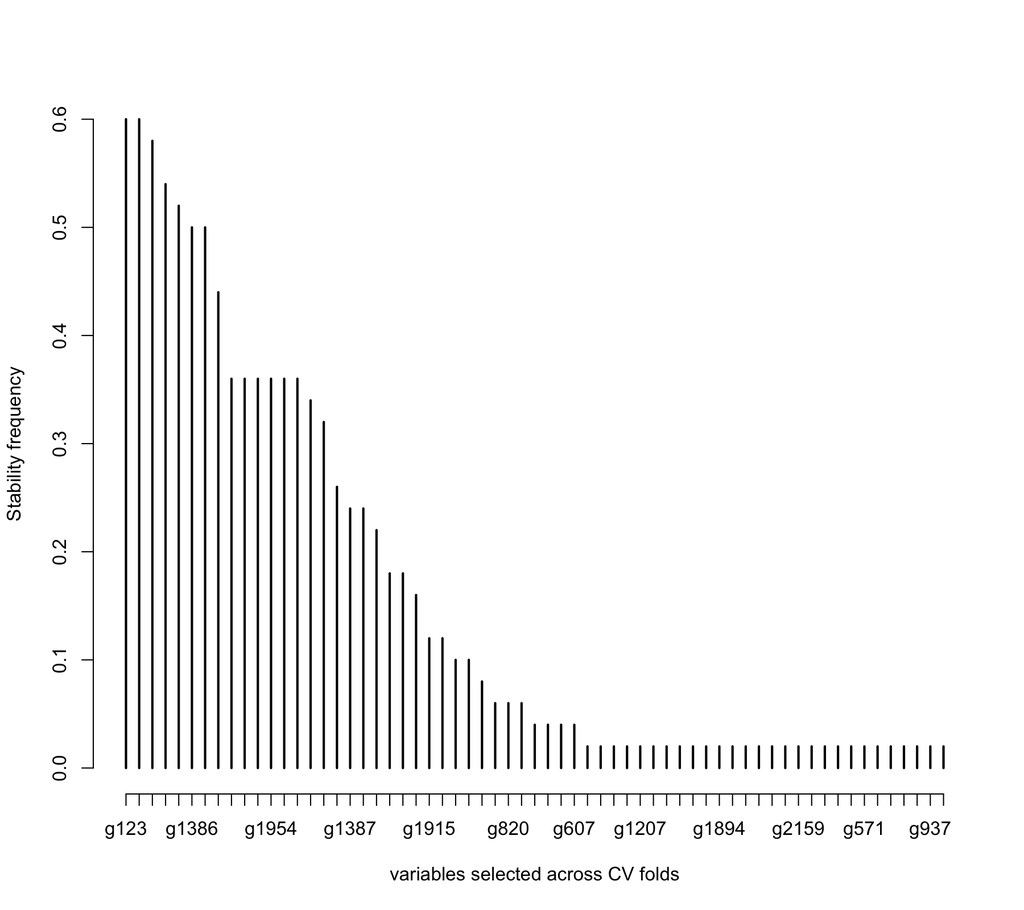

```r
#this is for comp 1
plot(perf.splsda$features$stable[[1]], type = 'h',
     xlab = 'variables selected across CV folds', ylab = 'Stability frequency', title='Feature stability for comp = 1')
```

```r
# just the head of the selectVar output:
head(selectVar(splsda.srbct, comp = 2)$value)
```

|  | value.var |
| --- | --- |
| g1389 | -0.4234165 |
| g246 | -0.3464390 |
| g1954 | -0.3399525 |
| g545 | -0.3343542 |
| g1319 | -0.2520065 |
| g1074 | -0.2335000 |

```r
# save the name of selected var + stability from perf:
select.name <- selectVar(splsda.srbct, comp = 2)$name
stability <- perf.splsda$features$stable[[2]][select.name]
# just the head of the stability of the selected var:
head(cbind(selectVar(splsda.srbct, comp = 2)$value, stability))
```

|  | value.var | Var1 | Freq |
| --- | --- | --- | --- |
| g1389 | -0.4234165 | g1389 | 0.4 |
| g246 | -0.3464390 | g246 | 0.4 |
| g1954 | -0.3399525 | g1954 | 0.4 |
| g545 | -0.3343542 | g545 | 0.4 |
| g1319 | -0.2520065 | g1319 | 0.4 |
| g1074 | -0.2335000 | g1074 | 0.4 |

# Variable Plots

We can represent the genes selected with sPLS-DA on correlation circles using the function **plotVar()**. More information on how to interpret the correlation circle plots can be found in [2](http://biodatamining.biomedcentral.com/articles/10.1186/1756-0381-5-19).

Here we use the truncated gene names as variable names in *var.names*:

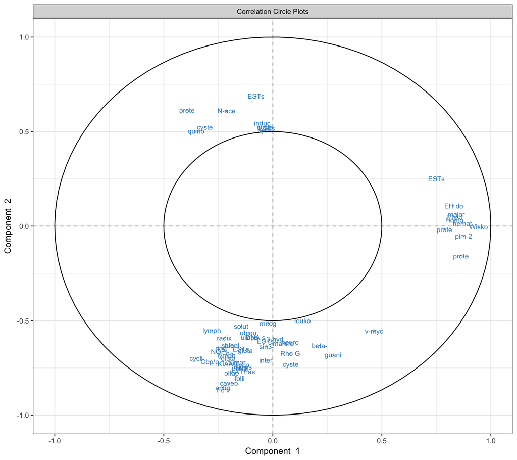

```r
plotVar(splsda.srbct, comp = c(1,2),
        var.names = list(substr(srbct$gene.name[, 2], 1, 5)), cex = 3)
```

We can also represent the loading weight of each selected variable on each component using the function **plotLoadings()**. The colors indicate the group in which the expression of the selected gene is maximal based on the mean ( *method* = ’median’ is also available for skewed or count data).

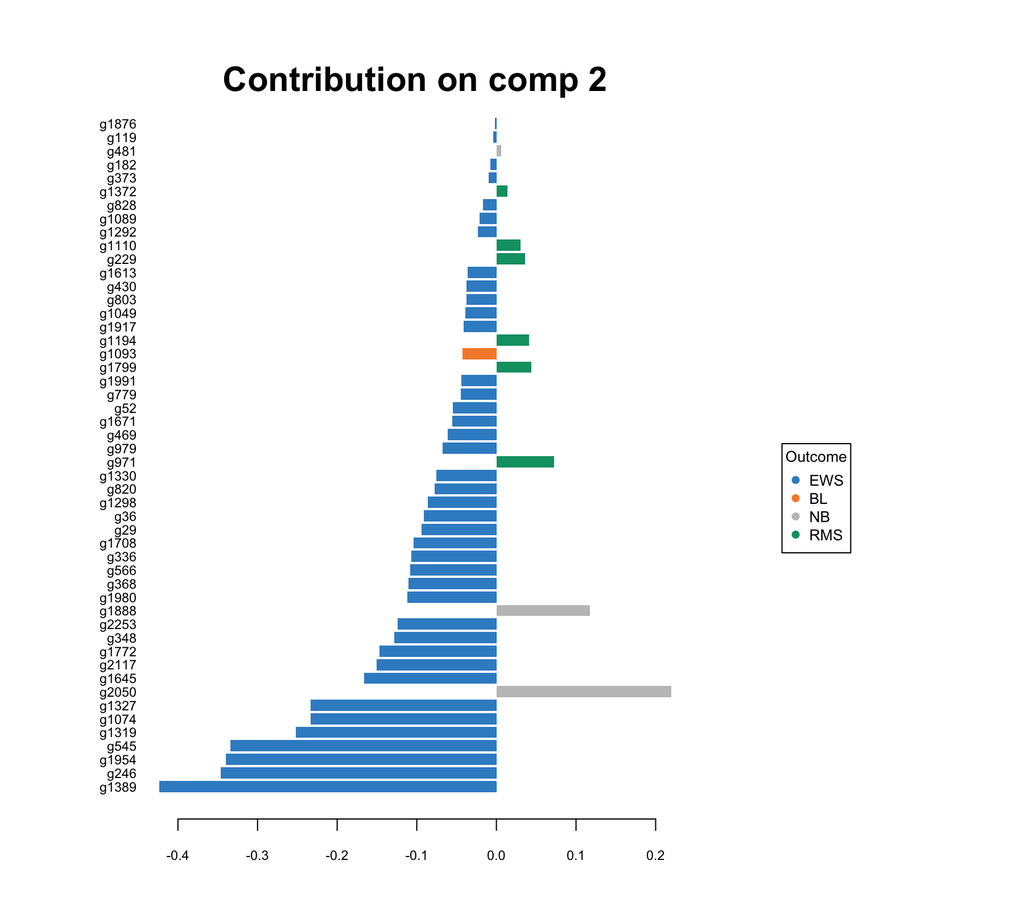

```r
plotLoadings(splsda.srbct, comp = 2, method = 'mean', contrib = 'max')
```

The most important variable are ranked from the bottom of the graph (long bar). Negative and positive signs indicate the correlation structure between variables.

# Prediction with sPLS-DA

The code below artificially creates an ‘external’ test set on which we want to predict the class membership. Here we display this code as an example. A real case scenario would include a real external test set, normalised similarly to the training set.

```r
set.seed(33)
train <- sample(1:nrow(X), 50)    # randomly select 50 samples in the training set
test <- setdiff(1:nrow(X), train) # rest is part of the test set

# store matrices into training and test set:
X.train <- X[train, ]
X.test <- X[test,]
Y.train <- Y[train]
Y.test <- Y[test]

# check dimensions are OK:
dim(X.train)
```

```
## [1]   50 2308
```

```r
dim(X.test)
```

```
## [1]   13 2308
```

It is really important to tune only on the training data to avoid overly optimistic performance results.

```r
#this chunk takes ~ 6 min to run
set.seed(32)

tune.splsda.train.srbct <- tune.splsda(X.train, Y.train, ncomp = 4, validation = 'Mfold', folds = 5, progressBar = FALSE, dist = 'mahalanobis.dist', test.keepX = list.keepX, nrepeat = 50) #nrepeat 50-100
```

Given the above tuning we obtain *ncomp* = 3 and *keepX* = c(20,30,40).

```r
splsda.srbct.train <- splsda(X.train, Y.train, ncomp = 3, keepX = c(20,30,40))
```

We now apply the trained model on the test set and we specify the prediction distance, for example mahalanobis.dist (see also **?predict.splsda** ):

```r
splsda.srbct.predict <- predict(splsda.srbct.train, X.test,
                       dist = "mahalanobis.dist")
```

The object **$class** outputs the predicted classes of the test individual for each of the 3 components, conditionally on the previous component. We can compare the prediction to the real class (note: in a real application case you may never know the true class).

```r
# just the head:
head(data.frame(splsda.srbct.predict$class, Truth = Y.test))
```

|  | mahalanobis.dist.comp.1 | mahalanobis.dist.comp.2 | mahalanobis.dist.comp.3 | Truth |
| --- | --- | --- | --- | --- |
| EWS.T6 | EWS | EWS | EWS | EWS |
| EWS.T7 | EWS | EWS | EWS | EWS |
| EWS.T14 | NB | EWS | EWS | EWS |
| EWS.C11 | EWS | EWS | EWS | EWS |
| NB.C2 | EWS | RMS | NB | NB |
| NB.C9 | NB | NB | NB | NB |

```r
# compare prediction on the third component
table(splsda.srbct.predict$class$mahalanobis.dist[,3], Y.test)
```

```
##      Y.test
##       EWS BL NB RMS
##   EWS   4  0  0   0
##   NB    0  0  3   0
##   RMS   0  0  0   6
```

The object **$predict** outputs a ‘confidence measure’ for each test observation and each class level for a given component. The final prediction call is given based on this matrix and the distance that is specified.

```r
#On component 4, just the head:
kable(head(splsda.srbct.predict$predict[, , 3]))
```

|  | EWS | BL | NB | RMS |
| --- | --- | --- | --- | --- |
| EWS.T6 | 0.7993849 | 0.0191744 | -0.0308912 | 0.2123318 |
| EWS.T7 | 0.9907027 | 0.0014296 | -0.0323692 | 0.0402369 |
| EWS.T14 | 1.1230213 | -0.0628304 | -0.1212614 | 0.0610704 |
| EWS.C11 | 0.8377773 | 0.0120639 | 0.1234204 | 0.0267384 |
| NB.C2 | 0.1487572 | 0.1229675 | 0.6182326 | 0.1100428 |
| NB.C9 | 0.0631024 | 0.0213983 | 0.9781835 | -0.0626842 |

Above we output the confidence measure for the 3rd component. The columns represent the different class labels.

# References

1. [Khan, J., Wei, J.S., Ringner, M., Saal, L.H., Ladanyi, M., Westermann, F., Berthold, F., Schwab, M., Antonescu, C.R., Peterson, C. and Meltzer, P.S., 2001. Classification and diagnostic prediction of cancers using gene expression profiling and artificial neural networks. Nature medicine, 7(6), pp.673-679.](https://scholar.google.com/scholar_url?url=http://www.nature.com/nm/journal/v7/n6/full/nm0601_673.html&hl=en&sa=T&oi=gsb-gga&ct=res&cd=0&ei=H75IWOC3AYK3jAH_urXIDA&scisig=AAGBfm1jtfJyzuB3S-5oLiyMsMLY-eGJDA)
2. [González, I., Lê Cao, K.A., Davis, M.J. and Déjean, S., 2012. Visualising associations between paired ‘omics’ data sets. BioData mining, 5(1), p.1.](http://biodatamining.biomedcentral.com/articles/10.1186/1756-0381-5-19)
3. [Lê Cao, K.A., Boitard, S. and Besse, P., 2011. Sparse PLS discriminant analysis: biologically relevant feature selection and graphical displays for multiclass problems. BMC bioinformatics, 12(1), p.1. Vancouver](http://bmcbioinformatics.biomedcentral.com/articles/10.1186/1471-2105-12-253)